# Exponential functions in growth

Jeffrey A. Walker

4/4/2018

The population size at time $t$ is $N_t$. One day later, the population has doubled in size – it is two times ($2 \times$) bigger. And one day later, the population is again $2 \times$ bigger than the day before. That is, the rate that the population is increasing is constant. This is the rate constant $k$ Here $k=2$. The function to describe this growth is

$N_{t+1} = 2N_t$

Here we plot the function

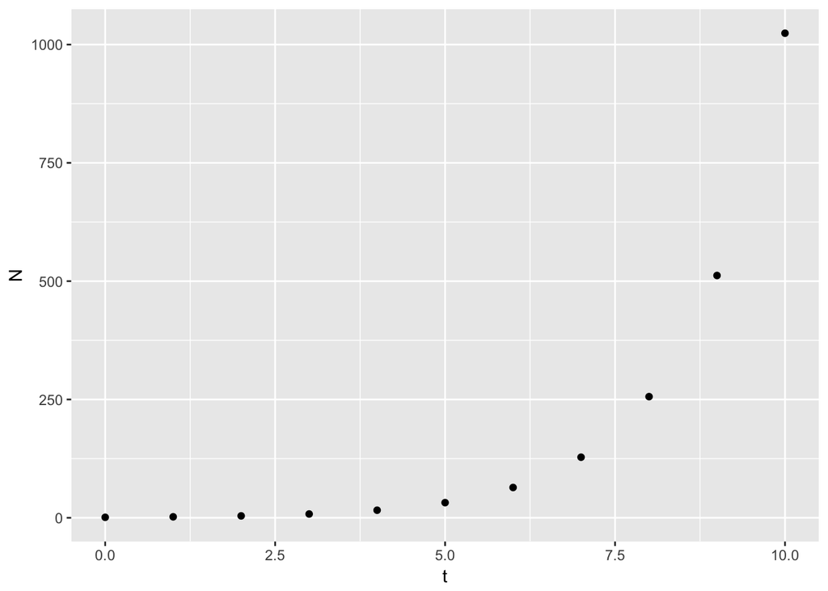

```r
k <- 2
t_inc <- 1
t0 <- 0
tf <- 10
t <- seq(t0, tf, by=t_inc)
No <- 1
N <- rep(No,length(t))
for(i in 2:length(t)){
  N[i] <- k*N[i-1]
}
qplot(t, N)
```

What is the rate constant if the output is the same (after 1 day, the size is twice that the day before) but the time increment is $\Delta t = 1/2$ day? The size after one day ($t+1$) is the size 1/2 day before times the new rate constant $k_2$

$$N_{t+1} = k_2N_{t + \Delta t}$$
and the size 1/2 day ago was the size one day ago times $k_2$

$$N_{t + \Delta t} = k_2N_{t}$$

Putting these together, the population size after one day (and two time increments that are each 1/2 day) is

$$N_{t+1} = k_2(k_2N_{t})$$
or

$$N_{t+1} = k_2^2N_{t}$$

If $N_{t+1}$ is the same regardless of the time increment then

$$k_2^2=k$$

and

$$k_2=k^\frac{1}{2} = k^{\Delta t}$$
Since in this example, $k=2$, the new rate constant is $\sqrt{2}$.

This can be generalized. Here $t+1$ means time $t$ plus one time increment ($\Delta t$), which isn’t necessarily one day. And, lets let $h=\Delta t$. Then

$$N_{t+1} = k^hN_t$$
How does N change over time generally? Subtract $N_t$ from both sides and divide both sides by $\Delta t$.

$$\frac{N_{t+1} - N_t}{\Delta t} = \frac{k^hN_t - N_t}{h}$$

(since, again, $h=\Delta t$). Substitute and re-arrange to get

$$\frac{\Delta N}{\Delta t} = \frac{k^h - 1}{h}N$$
Using calculus, when $\Delta t = h$ is infinitely small, then

$$\frac{dN}{dt} = \lim_{h\to 0} \frac{k^h - 1}{h}N = \textrm{ln}k$$

$k$ is the *finite growth rate* – the rate constant using discrete time steps. ln$k$ is the *intrinsic growth rate* – the rate constant for continuous growth.